# Final Project - Group 05

Nikhil Bhosale, Pooja Bendale, Ssanidhya Barraptay

2022-11-19

## Section 1 - Visualizing the data

Importing the standard libraries and packages:

#### We have imported the data from Cellphone.csv file and stored in the Cellphone variable.

```r
Cellphone <- read.csv("C:\\Users\\ACER\\Desktop\\DATA ANALYTICS\\Cellphone.csv",header=TRUE, stringsAsFactors=FALSE)
```

#### 1.1 Displayig the summary of Cellphone data

```r
summary(Cellphone)
```

```
##    Product_id         Price           Sale            weight
##  Min.   :  10.0   Min.   : 614   Min.   :  10.0   Min.   : 66.0
##  1st Qu.: 237.0   1st Qu.:1734   1st Qu.:  37.0   1st Qu.:134.1
##  Median : 774.0   Median :2258   Median : 106.0   Median :153.0
##  Mean   : 675.6   Mean   :2216   Mean   : 621.5   Mean   :170.4
##  3rd Qu.:1026.0   3rd Qu.:2744   3rd Qu.: 382.0   3rd Qu.:170.0
##  Max.   :1339.0   Max.   :4361   Max.   :9807.0   Max.   :753.0
##   resoloution         ppi           cpu.core        cpu.freq
##  Min.   : 1.40   Min.   :121.0   Min.   :0.000   Min.   :0.000
##  1st Qu.: 4.80   1st Qu.:233.0   1st Qu.:4.000   1st Qu.:1.200
##  Median : 5.15   Median :294.0   Median :4.000   Median :1.400
##  Mean   : 5.21   Mean   :335.1   Mean   :4.857   Mean   :1.503
##  3rd Qu.: 5.50   3rd Qu.:428.0   3rd Qu.:8.000   3rd Qu.:1.875
##  Max.   :12.20   Max.   :806.0   Max.   :8.000   Max.   :2.700
##   internal.mem        ram           RearCam        Front_Cam
##  Min.   :  0.0   Min.   :0.000   Min.   : 0.00   Min.   : 0.000
##  1st Qu.:  8.0   1st Qu.:1.000   1st Qu.: 5.00   1st Qu.: 0.000
##  Median : 16.0   Median :2.000   Median :12.00   Median : 5.000
##  Mean   : 24.5   Mean   :2.205   Mean   :10.38   Mean   : 4.503
##  3rd Qu.: 32.0   3rd Qu.:3.000   3rd Qu.:16.00   3rd Qu.: 8.000
##  Max.   :128.0   Max.   :6.000   Max.   :23.00   Max.   :20.000
##     battery       thickness
##  Min.   : 800   Min.   : 5.100
##  1st Qu.:2040   1st Qu.: 7.600
##  Median :2800   Median : 8.400
##  Mean   :2842   Mean   : 8.922
##  3rd Qu.:3240   3rd Qu.: 9.800
##  Max.   :9500   Max.   :18.500
```

#### 1.2 To find out the Data type of all enteties:

```r
str(Cellphone)
```

```
## 'data.frame':    161 obs. of  14 variables:
##  $ Product_id  : int  203 880 40 99 880 947 774 947 99 1103 ...
##  $ Price       : int  2357 1749 1916 1315 1749 2137 1238 2137 1315 2580 ...
##  $ Sale        : int  10 10 10 11 11 12 13 13 14 15 ...
##  $ weight      : num  135 125 110 118 125 ...
##  $ resoloution : num  5.2 4 4.7 4 4 5.5 4 5.5 4 5.1 ...
##  $ ppi         : int  424 233 312 233 233 401 233 401 233 432 ...
##  $ cpu.core    : int  8 2 4 2 2 4 2 4 2 4 ...
##  $ cpu.freq    : num  1.35 1.3 1.2 1.3 1.3 2.3 1.2 2.3 1.3 2.5 ...
##  $ internal.mem: num  16 4 8 4 4 16 8 16 4 16 ...
##  $ ram         : num  3 1 1.5 0.512 1 2 1 2 0.512 2 ...
##  $ RearCam     : num  13 3.15 13 3.15 3.15 16 2 16 3.15 16 ...
##  $ Front_Cam   : num  8 0 5 0 0 8 0 8 0 2 ...
##  $ battery     : int  2610 1700 2000 1400 1700 2500 1560 2500 1400 2800 ...
##  $ thickness   : num  7.4 9.9 7.6 11 9.9 9.5 11.7 9.5 11 8.1 ...
```

We have used str() to find out the datatype for each attribute.

#### 1.3 To determine the number of null values in given data.

```r
null_values <- sum(is.na(Cellphone))
null_values
```

```
## [1] 0
```

From the above output we can see that their are 0 null values.

#### 1.4 To determine the numbers of duplicate values in given data.

```r
duplicate_values_old <- sum(duplicated(Cellphone))
duplicate_values_old
```

```
## [1] 0
```

From the above output we can see that their are 0 duplicate values.

#### 1.5 To detrmine the correlations between all entities:

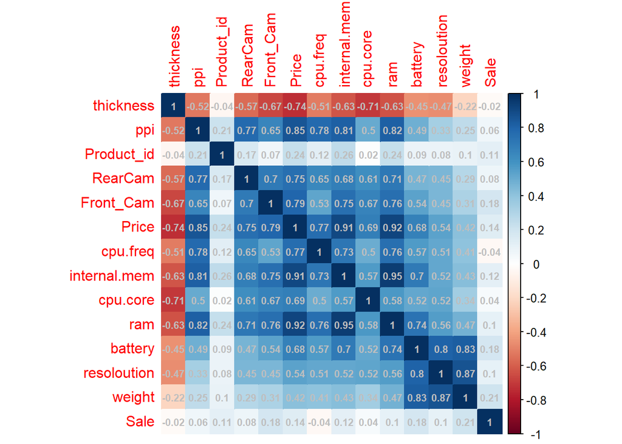

```r
mydata.cor = cor(Cellphone, method = "spearman")
corrplot(mydata.cor, method = "color", addCoef.col="grey", order = "AOE" ,number.cex=0.70 )
```

As seen above, we have represented the correlation matrix using the corrplot function.

## Section 2 - Graphical Overview

#### 2.1 Histogram to show number of Phones by Price

> we can plot graph using hist() function.

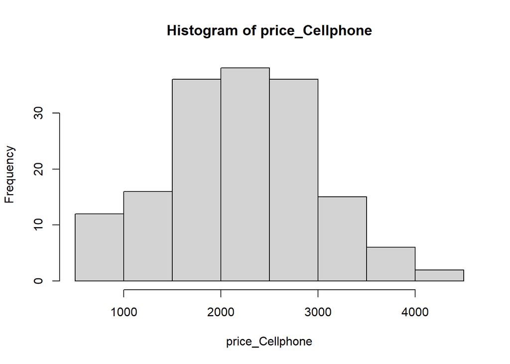

```r
price_Cellphone <- Cellphone$Price
hist(price_Cellphone)
```

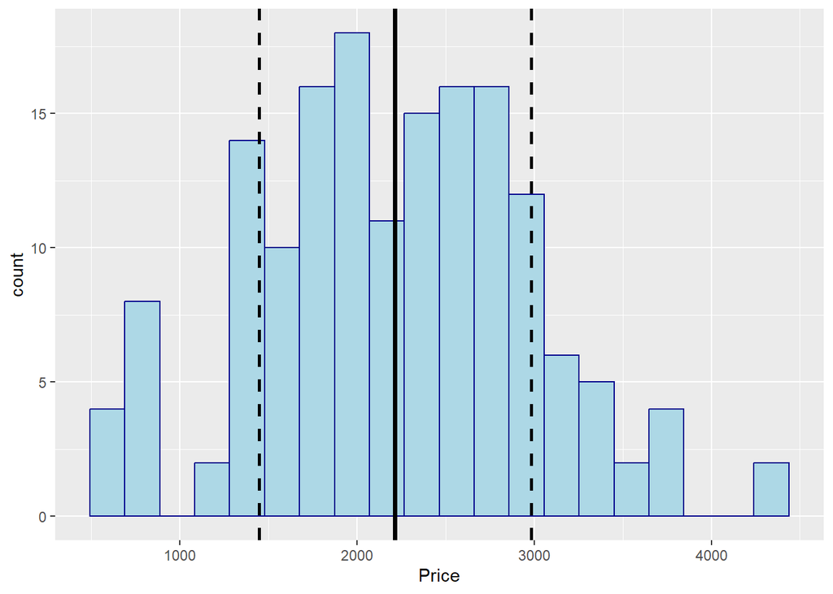

```r
ggplot(Cellphone, aes(Price)) +
  geom_histogram(color = "darkblue", fill = "lightblue", bins = 20) +
  geom_vline(aes(xintercept = mean(Price)), color = "#000000", linewidth = 1.25) +
  geom_vline(aes(xintercept = mean(Price) + sd(Price)), color = "#000000", linewidth = 1, linetype = "dashed") +
  geom_vline(aes(xintercept = mean(Price) - sd(Price)), color = "#000000", linewidth = 1, linetype = "dashed") +
  scale_fill_gradient("Legend",low = "green", high = "blue")
```

#### 2.2 Boxplot to show number Price of cell phones.

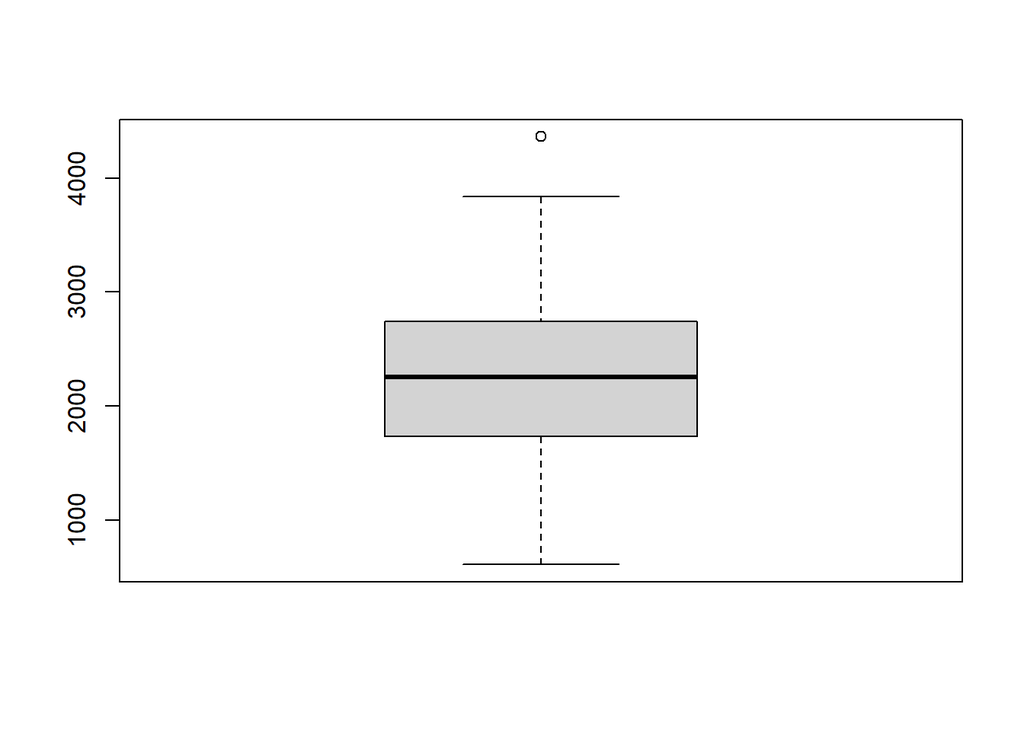

```r
price_Cellphone <- Cellphone$Price
boxplot(price_Cellphone)
```

```r
summary(price_Cellphone)
```

```
##    Min. 1st Qu.  Median    Mean 3rd Qu.    Max.
##     614    1734    2258    2216    2744    4361
```

Minimum value for price is approximately 500 and Max value is above 4000. Having median is around 2200. Price entity contains only one Outlier.

#### 2.3 Overlay Diagram - To plot the diagram for the price.

> Overlay Histogram alog with Boxplot

```r
new_cellphone <- dplyr::mutate(Cellphone ,highlowprice = case_when(Price <= 1500 ~ 'low' ,Price > 1500 & Price <= 3000 ~ 'Medium' ,Price > 3000 ~ 'High'))
```

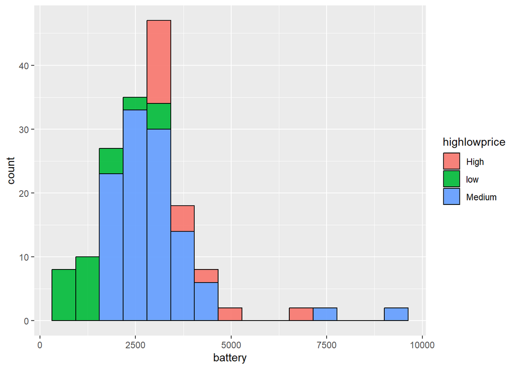

```r
par(mfrow=c(1,2))
ggplot(new_cellphone,aes(x = battery , fill = highlowprice)) + geom_histogram(alpha = 0.9, bins = 15,color = "black")
```

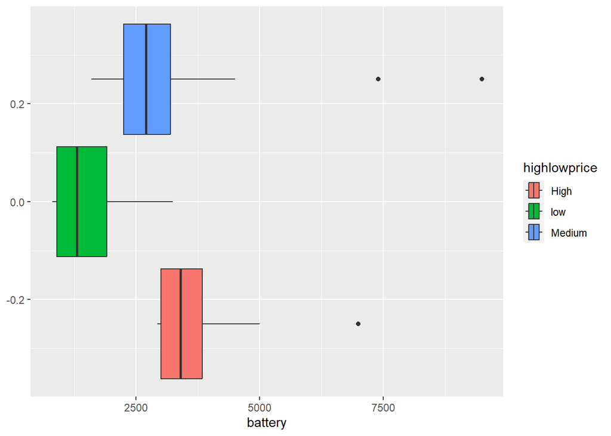

```r
ggplot(data = new_cellphone ,mapping = aes(x = battery)) + geom_boxplot(aes( fill = highlowprice))
```

## Section 3 - Hypothesis Testing

#### 3.1 CASE 1

**Parameters:**

**Hypotheses:**

*Null Hypothesis:* Population mean of Price is directly proportional to that of weight.

*Alternate Hypothesis:* Population mean of Price is not proportional to that of weight.

$$H_0: \mu_{P} = \mu_{W} \qquad H_1:
\mu_{P} \ne \mu_{W}$$

```r
t.test(Cellphone$Price, Cellphone$weight, var.equal = TRUE, conf.level = 0.95)
```

```
##
##  Two Sample t-test
##
## data:  Cellphone$Price and Cellphone$weight
## t = 33.537, df = 320, p-value < 2.2e-16
## alternative hypothesis: true difference in means is not equal to 0
## 95 percent confidence interval:
##  1925.193 2165.148
## sample estimates:
## mean of x mean of y
## 2215.5963  170.4261
```

As we can see the p-value is less than α, we should reject the Null Hypothesis. Similarly, We can define the test of proportionality of variances as follows:

$$H_0: \sigma_P^2/\sigma_W^2 =1 \qquad
H_1: \sigma_P^2/\sigma_W^2 \ne 1$$

```r
var.test(Cellphone$Price, Cellphone$weight, alternative = "two.sided")
```

```
##
##  F test to compare two variances
##
## data:  Cellphone$Price and Cellphone$weight
## F = 68.393, num df = 160, denom df = 160, p-value < 2.2e-16
## alternative hypothesis: true ratio of variances is not equal to 1
## 95 percent confidence interval:
##  50.11199 93.34191
## sample estimates:
## ratio of variances
##           68.39261
```

Here the p value is again less than α, hence we reject Null hypothesis. As the statistic provides evidence against and in favor of alternate hypothesis

Below we have graphically represented the t-statistic.

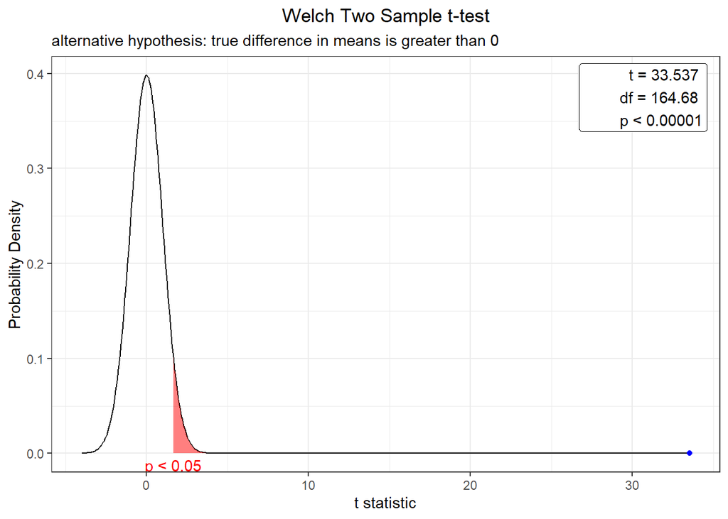

```r
plot(t.test(Cellphone$Price, Cellphone$weight, var.equal = FALSE, conf.level = 0.95, alternative = "greater"))
```

#### 3.2 CASE 2

**Parameters:**

The numerical measurements are ram and price, and the parameters of interest are population mean of ram and price.

**Hypotheses:**

*Null Hypothesis:* Population mean of ram is directly proportional to that of price.

*Alternate Hypothesis:* Population mean of ram is not proportional to that of price.

$$H_0: \mu_R =\mu_P \qquad H_1: \mu_R \ne
\mu_P$$

```r
t.test(Cellphone$ram, Cellphone$Price, var.equal = TRUE, conf.level = 0.95)
```

```
##
##  Two Sample t-test
##
## data:  Cellphone$ram and Cellphone$Price
## t = -36.56, df = 320, p-value < 2.2e-16
## alternative hypothesis: true difference in means is not equal to 0
## 95 percent confidence interval:
##  -2332.501 -2094.281
## sample estimates:
##   mean of x   mean of y
##    2.204994 2215.596273
```

As we can see the p-value is less than α, we should reject the Null Hypothesis. Similarly, We can define the test of proportionality of variances as follows:

$$H_0: \sigma_R^2 /\sigma_P^2 = 1 \qquad
H_1: \sigma_R^2 /\sigma_P^2 \ne 1$$

```r
var.test(Cellphone$ram, Cellphone$Price, alternative = "two.sided")
```

```
##
##  F test to compare two variances
##
## data:  Cellphone$ram and Cellphone$Price
## F = 4.3916e-06, num df = 160, denom df = 160, p-value < 2.2e-16
## alternative hypothesis: true ratio of variances is not equal to 1
## 95 percent confidence interval:
##  3.217801e-06 5.993689e-06
## sample estimates:
## ratio of variances
##        4.39164e-06
```

Here the p value is again less than α, hence we reject Null hypothesis. As the statistic provides evidence against and in favor of alternate hypothesis

Below we have graphically represented the t-statistic.

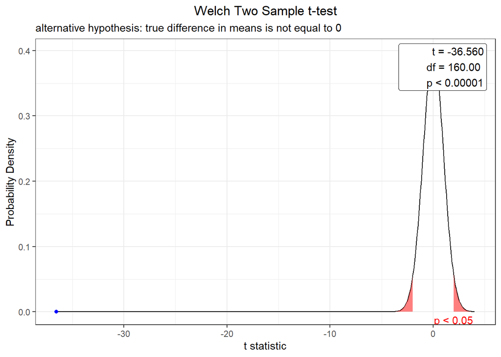

```r
plot(t.test(Cellphone$ram, Cellphone$Price, var.equal = FALSE, conf.level = 0.95))
```

## Section 4 - Linear Regression Using Akieke Information Theory

#### Using Scale to standardize the data

```r
cellData <- scale(Cellphone)
cellData <- as.data.frame(cellData)
```

## Using set seed to make sure we produce output every time we run the code

```r
set.seed(30021)
```

#### 4.1 Train - Test Split

```r
#Splitting the dataset into 75% training and 25% testing
i = sample(2, nrow(cellData), replace = TRUE, prob = c(0.75,0.25))
CellPhone_Training <- cellData[i == 1,]
CellPhone_Testing <- cellData[i == 2,]
```

#### Dataset dimensions

```r
dim(CellPhone_Training)
```

```
## [1] 118  14
```

```r
dim(CellPhone_Testing)
```

```
## [1] 43 14
```

#### 4.2 Model 1 using AIC : Forward Model Propogation

```r
init_model <- lm(Price ~ 1, data = CellPhone_Training[,1:14])
all_model <- lm(Price ~ ., data = CellPhone_Training[,1:14])
forwardModel <- stepAIC(init_model, direction = "forward" , scope = formula(all_model))
```

```
## Start:  AIC=1.8
## Price ~ 1
##
##                Df Sum of Sq     RSS      AIC
## + ram           1    97.378  20.418 -203.004
## + ppi           1    82.123  35.674 -137.160
## + internal.mem  1    76.211  41.585 -119.067
## + cpu.freq      1    63.764  54.033  -88.169
## + cpu.core      1    61.692  56.105  -83.729
## + RearCam       1    60.912  56.884  -82.101
## + thickness     1    58.558  59.239  -77.315
## + Front_Cam     1    53.389  64.408  -67.443
## + battery       1    42.166  75.630  -48.490
## + resoloution   1    21.814  95.982  -20.369
## + Sale          1    10.004 107.792   -6.676
## + weight        1     3.376 114.420    0.365
## + Product_id    1     2.572 115.224    1.191
## <none>                      117.796    1.796
##
## Step:  AIC=-203
## Price ~ ram
##
##                Df Sum of Sq    RSS     AIC
## + thickness     1    9.6740 10.744 -276.77
## + cpu.core      1    9.5351 10.883 -275.25
## + ppi           1    4.4932 15.925 -230.33
## + cpu.freq      1    4.4899 15.928 -230.31
## + RearCam       1    3.6544 16.764 -224.27
## + resoloution   1    1.8648 18.553 -212.31
## + Front_Cam     1    1.4903 18.928 -209.95
## + battery       1    0.9019 19.516 -206.34
## + Product_id    1    0.3923 20.026 -203.29
## <none>                      20.418 -203.00
## + internal.mem  1    0.0555 20.363 -201.32
## + weight        1    0.0333 20.385 -201.20
## + Sale          1    0.0107 20.407 -201.07
##
## Step:  AIC=-276.77
## Price ~ ram + thickness
##
```

[output cut: 81 more lines]

```
## + Product_id   1   0.03932 4.7093 -362.10
## + Front_Cam    1   0.02800 4.7206 -361.81
## + Sale         1   0.00652 4.7421 -361.28
##
## Step:  AIC=-373.55
## Price ~ ram + thickness + ppi + cpu.core + internal.mem + cpu.freq +
##     battery + weight
##
##               Df Sum of Sq    RSS     AIC
## <none>                     4.2736 -373.55
## + RearCam      1  0.056820 4.2168 -373.13
## + Front_Cam    1  0.047388 4.2262 -372.87
## + Sale         1  0.031766 4.2418 -372.43
## + resoloution  1  0.001056 4.2725 -371.58
## + Product_id   1  0.000489 4.2731 -371.56
```

#### 4.3 Summary of Forward Propogation Model

```r
summary(forwardModel)
```

```
##
## Call:
## lm(formula = Price ~ ram + thickness + ppi + cpu.core + internal.mem +
##     cpu.freq + battery + weight, data = CellPhone_Training[,
##     1:14])
##
## Residuals:
##      Min       1Q   Median       3Q      Max
## -0.50856 -0.15071  0.01616  0.13106  0.41764
##
## Coefficients:
##               Estimate Std. Error t value Pr(>|t|)
## (Intercept)   0.007418   0.018373   0.404  0.68721
## ram           0.240622   0.053389   4.507 1.66e-05 ***
## thickness    -0.161216   0.027438  -5.876 4.65e-08 ***
## ppi           0.187993   0.038561   4.875 3.72e-06 ***
## cpu.core      0.199516   0.029766   6.703 9.36e-10 ***
## internal.mem  0.236819   0.044837   5.282 6.60e-07 ***
## cpu.freq      0.063400   0.032457   1.953  0.05334 .
## battery       0.213145   0.055162   3.864  0.00019 ***
## weight       -0.165632   0.047585  -3.481  0.00072 ***
## ---
## Signif. codes:  0 '***' 0.001 '**' 0.01 '*' 0.05 '.' 0.1 ' ' 1
##
## Residual standard error: 0.198 on 109 degrees of freedom
## Multiple R-squared:  0.9637, Adjusted R-squared:  0.9611
## F-statistic: 361.9 on 8 and 109 DF,  p-value: < 2.2e-16
```

#### 4.4 Analysis of Variance of Forward model

```r
forwardModel$anova
```

```
## Stepwise Model Path
## Analysis of Deviance Table
##
## Initial Model:
## Price ~ 1
##
## Final Model:
## Price ~ ram + thickness + ppi + cpu.core + internal.mem + cpu.freq +
##     battery + weight
##
##
##             Step Df   Deviance Resid. Df Resid. Dev         AIC
## 1                                    117 117.796389    1.796213
## 2          + ram  1 97.3784487       116  20.417940 -203.003941
## 3    + thickness  1  9.6740034       115  10.743937 -276.768480
## 4          + ppi  1  2.3162266       114   8.427710 -303.420823
## 5     + cpu.core  1  1.5990355       113   6.828675 -326.247373
## 6 + internal.mem  1  1.7027796       112   5.125895 -358.092777
## 7     + cpu.freq  1  0.2660244       111   4.859871 -362.381390
## 8      + battery  1  0.1112588       110   4.748612 -363.114209
## 9       + weight  1  0.4750189       109   4.273593 -373.551106
```

#### 4.5 Finding the Mean Absolute Error on the Testing Dataset for Forward Propogation Model

```r
forward_pred <-predict(object = forwardModel, newdata = CellPhone_Testing[,1:14])
MAE(y_pred = forward_pred, y_true = CellPhone_Testing$Price)
```

```
## [1] 0.2410847
```

#### 4.6 Finding the Root Mean Squared Error on the Testing Dataset for Forward Propogation Model

```r
RMSE(y_pred = forward_pred, y_true = CellPhone_Testing$Price)
```

```
## [1] 0.2895925
```

#### 4.7 Plot of result

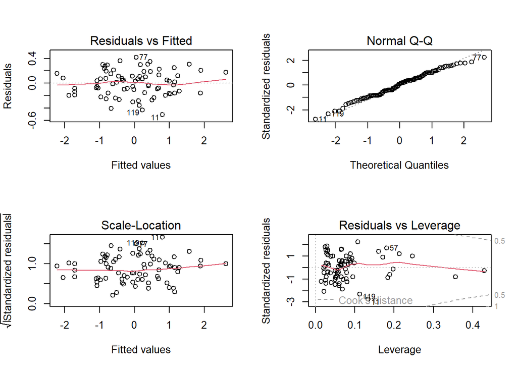

```r
par(mfrow=c(2,2))
plot(forwardModel)
```

### Model 2: Backward Model Propogation

#### 4.8

```r
backward_model = stepAIC(all_model ,direction = "backward")
```

```
## Start:  AIC=-366.18
## Price ~ Product_id + Sale + weight + resoloution + ppi + cpu.core +
##     cpu.freq + internal.mem + ram + RearCam + Front_Cam + battery +
##     thickness
##
##                Df Sum of Sq    RSS     AIC
## - Sale          1   0.00097 4.1804 -368.15
## - Product_id    1   0.00202 4.1814 -368.12
## - resoloution   1   0.01296 4.1924 -367.82
## - Front_Cam     1   0.01366 4.1931 -367.80
## - RearCam       1   0.03666 4.2161 -367.15
## - weight        1   0.06348 4.2429 -366.40
## <none>                      4.1794 -366.18
## - cpu.freq      1   0.15961 4.3390 -363.76
## - battery       1   0.50476 4.6842 -354.73
## - ram           1   0.51685 4.6962 -354.42
## - ppi           1   0.67455 4.8539 -350.53
## - thickness     1   0.89417 5.0736 -345.30
## - internal.mem  1   0.89423 5.0736 -345.30
## - cpu.core      1   1.18795 5.3673 -338.66
##
## Step:  AIC=-368.15
## Price ~ Product_id + weight + resoloution + ppi + cpu.core +
##     cpu.freq + internal.mem + ram + RearCam + Front_Cam + battery +
##     thickness
##
##                Df Sum of Sq    RSS     AIC
## - Product_id    1   0.00185 4.1822 -370.10
## - resoloution   1   0.01466 4.1950 -369.74
## - Front_Cam     1   0.02336 4.2037 -369.50
## - RearCam       1   0.03996 4.2203 -369.03
## - weight        1   0.06292 4.2433 -368.39
## <none>                      4.1804 -368.15
## - cpu.freq      1   0.16811 4.3485 -365.50
## - battery       1   0.50556 4.6859 -356.68
## - ram           1   0.52341 4.7038 -356.23
## - ppi           1   0.67683 4.8572 -352.45
## - thickness     1   0.89445 5.0748 -347.27
## - internal.mem  1   0.95602 5.1364 -345.85
## - cpu.core      1   1.18797 5.3683 -340.64
```

[output cut: 51 more lines]

```
##
## Step:  AIC=-373.55
## Price ~ weight + ppi + cpu.core + cpu.freq + internal.mem + ram +
##     battery + thickness
##
##                Df Sum of Sq    RSS     AIC
## <none>                      4.2736 -373.55
## - cpu.freq      1   0.14960 4.4232 -371.49
## - weight        1   0.47502 4.7486 -363.11
## - battery       1   0.58538 4.8590 -360.40
## - ram           1   0.79641 5.0700 -355.39
## - ppi           1   0.93189 5.2055 -352.27
## - internal.mem  1   1.09379 5.3674 -348.66
## - thickness     1   1.35354 5.6271 -343.08
## - cpu.core      1   1.76153 6.0351 -334.82
```

```r
summary(backward_model)
```

```
##
## Call:
## lm(formula = Price ~ weight + ppi + cpu.core + cpu.freq + internal.mem +
##     ram + battery + thickness, data = CellPhone_Training[, 1:14])
##
## Residuals:
##      Min       1Q   Median       3Q      Max
## -0.50856 -0.15071  0.01616  0.13106  0.41764
##
## Coefficients:
##               Estimate Std. Error t value Pr(>|t|)
## (Intercept)   0.007418   0.018373   0.404  0.68721
## weight       -0.165632   0.047585  -3.481  0.00072 ***
## ppi           0.187993   0.038561   4.875 3.72e-06 ***
## cpu.core      0.199516   0.029766   6.703 9.36e-10 ***
## cpu.freq      0.063400   0.032457   1.953  0.05334 .
## internal.mem  0.236819   0.044837   5.282 6.60e-07 ***
## ram           0.240622   0.053389   4.507 1.66e-05 ***
## battery       0.213145   0.055162   3.864  0.00019 ***
## thickness    -0.161216   0.027438  -5.876 4.65e-08 ***
## ---
## Signif. codes:  0 '***' 0.001 '**' 0.01 '*' 0.05 '.' 0.1 ' ' 1
##
## Residual standard error: 0.198 on 109 degrees of freedom
## Multiple R-squared:  0.9637, Adjusted R-squared:  0.9611
## F-statistic: 361.9 on 8 and 109 DF,  p-value: < 2.2e-16
```

```r
backward_model$anova
```

```
## Stepwise Model Path
## Analysis of Deviance Table
##
## Initial Model:
## Price ~ Product_id + Sale + weight + resoloution + ppi + cpu.core +
##     cpu.freq + internal.mem + ram + RearCam + Front_Cam + battery +
##     thickness
##
## Final Model:
## Price ~ weight + ppi + cpu.core + cpu.freq + internal.mem + ram +
##     battery + thickness
##
##
##            Step Df     Deviance Resid. Df Resid. Dev       AIC
## 1                                     104   4.179391 -366.1812
## 2        - Sale  1 0.0009720496       105   4.180363 -368.1538
## 3  - Product_id  1 0.0018480856       106   4.182211 -370.1017
## 4 - resoloution  1 0.0132941923       107   4.195505 -371.7272
## 5   - Front_Cam  1 0.0212675381       108   4.216773 -373.1305
## 6     - RearCam  1 0.0568199244       109   4.273593 -373.5511
```

#### 4.9

```r
backward_pred <-predict(object = backward_model, newdata = CellPhone_Testing[,1:14])
MAE(y_pred = backward_pred, y_true = CellPhone_Testing$Price)
```

```
## [1] 0.2410847
```

```r
RMSE(y_pred = backward_pred ,y_true = CellPhone_Testing$Price)
```

```
## [1] 0.2895925
```

#### 4.10

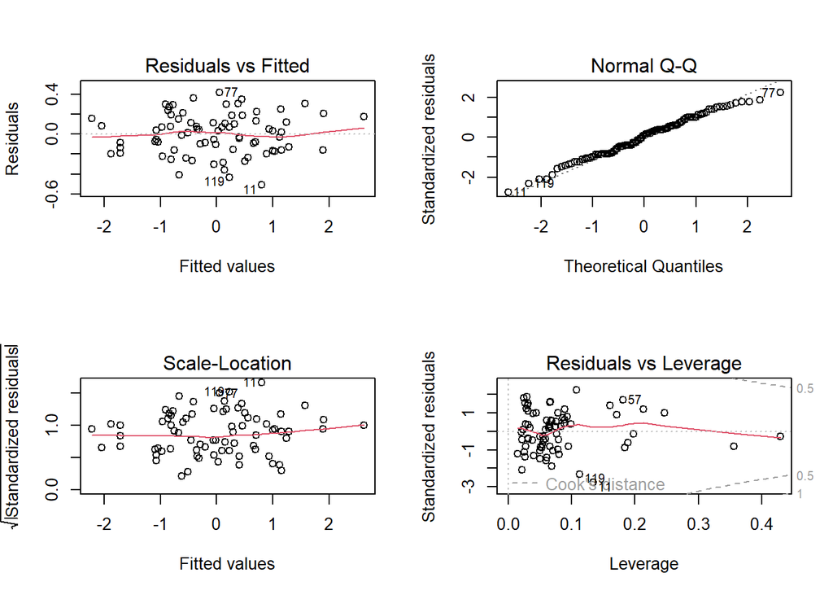

```r
par(mfrow = c(2,2))
plot(backward_model)
```